# CAP5771 Final Project

Exploration of Street Network Node and Edge Features.

Quentin Goss `quentingoss0323@floridapoly.edu`

## *Part 1 - Introduction*

The last version of this project may be found at the Github repository at https://github.com/QuentinGoss/CAP5771-Final-Project.

**Research Question:** What do the features of street network edges and vertices tell us about a street network, which features are dominant, and how can these features be used to make a general classification of a street network?

*Abstract*–One of the many steps in modeling transportation systems, is understanding the street network and the characteristics of the roads and intersections thereof. In this paper, we utilize R to perform principal component analysis and association rule learning to explore and classify the characteristics of a street network spatially.

*Index Terms*–transportation systems, street networks, association rule learning, principal component analysis

The transportation system (TS) is a complex arrangement of roads, highways, bridges, intersections, and infrastructure which traditionally provides the means of moving people and cargo from one place in the system to another in the least amount of time. Every TS is unique, and also imperfect since the layout of a TS is gradually implemented over ten or hundreds of years. During the expansion of a TS, it is unreasonable or impossible to predict the perfect expansion layout for the current moment as well for all potential futures. Often times, a government committee creates TS models to plan for TS expansion in the near future such as the 5 Year Consolidated Plan created by the Polk County Board of County Commissioners each year Hall et al. (n.d.).

The street network (SN) is the skeleton of a TS, as it consists of the paths that vehicles in a TS travel along to traverse the TS. These SNs may be represented as graphs $G = \{E,V\}$ which are a combination of intersections $V$ and road segments between intersections $E$. Realistic SNs, such those obtained from Open Street Maps (OSM) OpenStreetMap contributors (2019) are very detailed, including data about speed, highway type, merging rules at an intersection,priorities for edges to break same-arrival ties at intersections, etc.

Many TS modeling tools utilize SNs and the OSM SNs such as OSMnx for analysis and model construction Boeing (2017), CrowdSenSim for building crowdsensing models Fiandrino et al. (2017), and by Vitello et al. (2018) in their tool for pedestrian mobility modeling.

We will be using a SN retrieved from OSM, of which the drivable roads are filtered and that is converted into SUMO SN format, which is easier to work with.

Edges may contain data such as speed, type, priority, and name, along with graph information such as the vertex id that it begins and ends at. The nodes (vertices) are simpler, they contain spatial information, and a type, which are tie-breaking rules when two vehicles enter the vertex, which decides a vehicle to move first when they arrive at an intersection at the same time. For our proposed approach, we will first pre-process the SN data using Python to format it into CSV (comma separated value) format. Then, we will utilize R to explore the SN data, performing principal component analysis (PCA) to determine which edge properties are most important to defining the edges of a SN, and also association rule learning using the Apriori algorithm to create association rules that can be used to model a similar SN, or to be used to enhance the quality of a dimension reduced SN.

We will use the term **“nodes”** in place of **“vertices”** for the remainder of this report as it is convention when working with OSM and SUMO SN data.

## *Part 2 - Exploratory Data Analysis (EDA)*

We have selected a $5000m^2$ SN of Orlando to explore. We will perform EDA on the **nodes** first, then on the **edges**.

```r
library(tidyverse)
library(dplyr)
library(cowplot)
```

#### Nodes

```r
node.csv <- "https://raw.githubusercontent.com/QuentinGoss/CAP5771-Final-Project/master/data/node.csv"
nodes.raw <- read.csv(node.csv)
```

The **nodes** are basic. In most cases with SUMO SNs, only four of the fields are utilizied. For brevity those four are as follows:

| Feature | Description |
| --- | --- |
| id | Unique Identifier |
| x | x coordinate |
| y | y coordinate |
| type | Rules for resolving same-time arrival conflicts |

The **type** options are self exclamatory – they may be any of the following: priority, traffic_light, right_before_left, unregulated, allway_stop, rail_signal, zipper, traffic_light_right_on_red, and rail_crossing.

```r
paste0('Rows: ',nrow(nodes.raw))
```

```
## [1] "Rows: 3425"
```

```r
summary(nodes.raw)
```

```
##           id             x                y             z
##  1201200159:   1   Min.   : 388.1   Min.   : 297.5   Mode:logical
##  1201200164:   1   1st Qu.:2020.0   1st Qu.:2134.4   NA's:3425
##  1201200194:   1   Median :2986.0   Median :3168.5
##  1201200198:   1   Mean   :2909.8   Mean   :3145.8
##  1201200223:   1   3rd Qu.:3824.2   3rd Qu.:4157.2
##  1306186991:   1   Max.   :5210.8   Max.   :5777.5
##  (Other)   :3419
##                 type       tlType                 tl        radius
##  dead_end         :   5   Mode:logical             :3265   Mode:logical
##  priority         :3251   NA's:3425      joinedS_0 :   2   NA's:3425
##  right_before_left:   9                  1700923661:   1
##  traffic_light    : 160                  3675134324:   1
##                                          4860700048:   1
##                                          542892026 :   1
##                                          (Other)   : 154
##  keepClear      rightOfWay
##  Mode:logical   Mode:logical
##  NA's:3425      NA's:3425
##
##
##
##
##
```

We can’t do anthing with the node data related to our research question because: 1. The node type is not numerical 2. The node type is the only feature aside from **x**,**y** and **id**, which are not relevant to the research question. 3. This SN doesn’t have any other node features of importance.

Therefore, after EDA of the node data, we reach conclusion 1.

**Conclusion 1:** We may not apply principal component analysis to the node data, nor may we apply association rules learning to the node data because there is only one relavant categorical feature. Therefore, we do not consider node data to be considered in the classification of the SN.

#### Edges

```r
edge.csv <- "https://raw.githubusercontent.com/QuentinGoss/CAP5771-Final-Project/master/data/edge.csv"
edges.raw <- read.csv(edge.csv)
```

The edges of the SN seem to be much more promising to describe the SN than the nodes with 24 features.

| Feature | Description |
| --- | --- |
| id | Edge ID |
| from | Starting node ID. |
| to | Ending node ID |
| type | Classification of road (i.e Interstates and County Roads) |
| numLanes | The amount of lanes. |
| speed | Speed limit (meters/second) |
| spreadType | Which lane vehicles default to when entering the edge {“right”,“center”} |
| width | Road width (meters) |
| name | Name of the real-life road that the edge corresponds with. A blank name means offramp or trivial connector road. |
| endOffset | The distance the edge if differnt than the (x,y) of **to**. |
| sidewalkWidth | Width of the sidewalk |
| length | Length of the edge (meters) |

The remaining columns are the vehicle types that are allowed to travel on the edge.

Now we take a subset of the data, and clean it up. As stated in the research question, we will be performing principal Component Analysis (PCA) and Association Rules Learning (ARL), therefore we should select quantitative features for PCA and categorical features for ARL.

*Columns that will be pruned:*  
**id**, **from**, and **to** consist of features that are unique to this SN and no other. These are defined by OSM, and are unique to itself from the set of every edge in the world. **width**, **endOffset** and **sidewalkWidth** are full of ’’. Finally we prune the allowed vehicle type columns **emergency** $\cdots$ **moped** because the values are uniform across the entire dataset.

*Rows that will be pruned:*  
The 269 rows that have ’’ as the **name** will be trimmed. This will leave 7074 edges, a significant amount.

*Values that will be modified:*  
`NA` values of **spreadType** will be changed to “right”, the default for SUMO edges.

*Note:* We have opted to keep the **name** feature, since road names are often commonplace, as is known from the *Census and You*, a document by the U. S. Department of Commerce (1993).

The code for cleaning the data.

```r
# Trim the decided columns
edges <- edges.raw[,c('type','numLanes','speed','priority','spreadType','name','length')]

# Trim rows where name = NA
edges <- edges[which(edges$name != ''),]

# Change spreadType '' to 'right'
levels(edges$spreadType)[levels(edges$spreadType) == ''] <- 'right'

summary(edges)
```

```
##                    type         numLanes         speed
##  highway.residential :3893   Min.   :1.000   Min.   :11.18
##  highway.tertiary    :1354   1st Qu.:1.000   1st Qu.:13.89
##  highway.secondary   : 896   Median :1.000   Median :13.89
##  highway.primary     : 668   Mean   :1.275   Mean   :16.17
##  highway.unclassified: 214   3rd Qu.:1.000   3rd Qu.:17.88
##  highway.motorway    :  49   Max.   :6.000   Max.   :29.06
##  (Other)             :   0
##     priority       spreadType                   name
##  Min.   : 4.000   right :6202   Central Boulevard : 164
##  1st Qu.: 4.000   center: 872   Washington Street : 164
##  Median : 4.000                 Summerlin Avenue  : 162
##  Mean   : 5.328                 Mills Avenue      : 153
##  3rd Qu.: 6.000                 Westmoreland Drive: 142
##  Max.   :13.000                 Amelia Street     : 139
##                                 (Other)           :6150
##      length
##  Min.   :  0.236
##  1st Qu.: 21.064
##  Median : 53.082
##  Mean   : 69.526
##  3rd Qu.: 99.742
##  Max.   :605.580
##
```

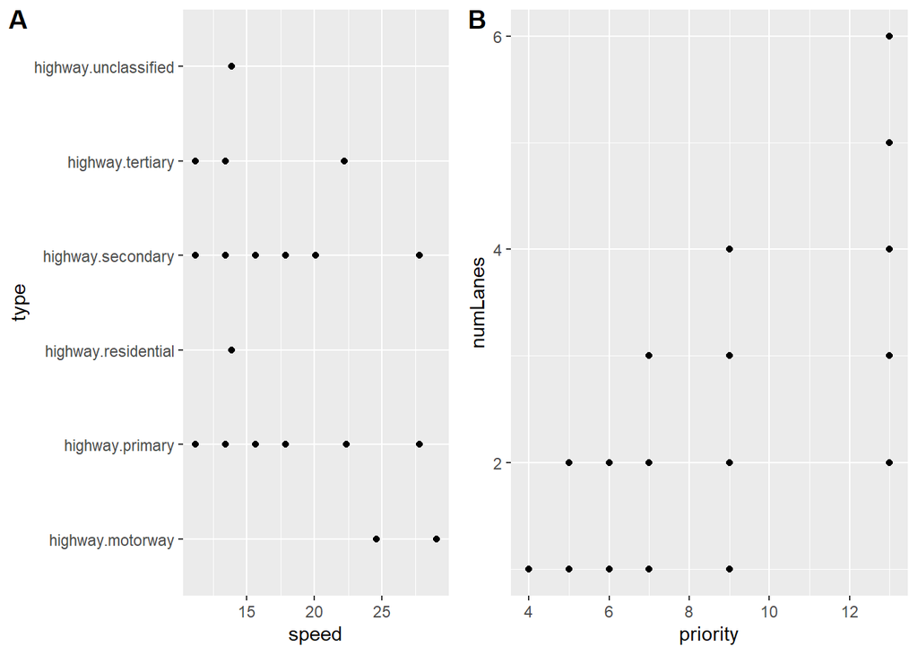

```r
type.vs.speed <- ggplot(edges, aes(x=speed, y=type)) + geom_point()
priority.vs.numlanes <- ggplot(edges, aes(x=priority, y=numLanes)) + geom_point()
plot_grid(type.vs.speed, priority.vs.numlanes, labels= "AUTO")
```

#### *EDA Conclusions*

During EDA we have realized that the node data does not have enough features to perform PCA or ARL to reach a generalization or classification of the SN after the **id**, **x**, **y**, and empty columns are pruned, leaving one feature.

Even without the node data, the edge data satisfies the PCA and ARL applicability conditions of the research question, therefore we may proceed to the methodology portion.

## *Part 3 - Methods*

#### *Principal Component Analysis*

While PCA is available in base R, we will use the `caret` and `ggfortify` packages for visualization.

```r
library(caret)
library(ggfortify)
```

During EDA, we identified 4 of the 7 features to be applicable for PCA. These features are **numLanes**, **speed**, **priority**, and **length**, which we create `edges.numeric`, as a subset of `edges`. When we perform PCA, we will *standardize* the data beforehand. The result of PCA are four principal components (PCs). The first three components cover 0.9631 of the cumulative proportion. This is a small reduction in dimension, and it lets us know that $\frac{1}{4}$ of the features must not have a large contribution.

```r
edges.numeric <- edges[,c('numLanes','speed','priority','length')]
pca.edges <- prcomp(edges.numeric, scale = TRUE)
summary(pca.edges)
```

```
## Importance of components:
##                           PC1    PC2    PC3     PC4
## Standard deviation     1.4067 0.9945 0.9405 0.38431
## Proportion of Variance 0.4947 0.2473 0.2211 0.03692
## Cumulative Proportion  0.4947 0.7420 0.9631 1.00000
```

Further inspection into the PCA results presented via biplot. Notably, we see that **speed**, **priority** and **numLanes** are moderately to highly correlated.

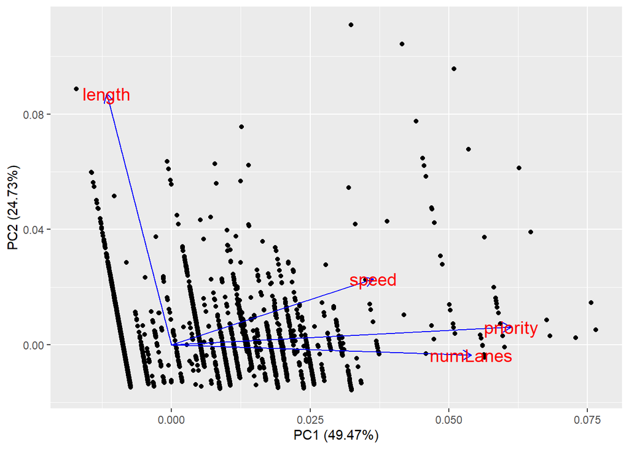

```r
autoplot(pca.edges, loadings.colour = 'blue', loadings = TRUE, loadings.label = TRUE, loadings.label.size = 5)
```

Notably, when we view the correlation plot of the features, WE find that **priorty** and **numLanes** are strongly correlated, and that **priority** and **speed** are moderately correlated. **Length** has very little, if any correlation to the other features.

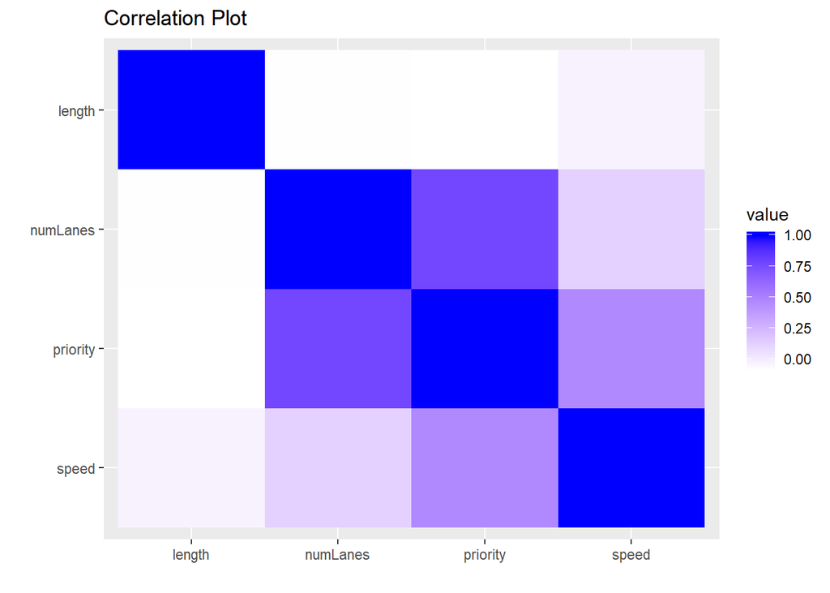

```r
edges.numeric.std <- edges.numeric %>%
    preProcess(method = c('center', 'scale')) %>%
    predict(edges.numeric)
autoplot(cor(edges.numeric.std)) +
    labs(x = '', y = '', title = 'Correlation Plot')
```

##### *PCA Conclusion*

Through PCA, we conclude that **speed**, **numLanes**, and **priority** are the optimal numerical features to classify a SUMO edge. This conclusion is supported by three observations:

1. The first three PCs have a cumulative proportion of 0.9631.
2. The biplot shows possible moderate/strong correlation of **speed**, **numLanes**, and **priority**.
3. The correlation plot clarifies the latter showing a strong correlation between **priority** and **numlanes**, and a moderate correlation between **priority** and **speed**.

**Conclusion 2:** The dominant numerical features of an edge are **numLanes**, **priority**, and **speed**.

#### *Association Rules Learning*

```r
library(arules)
```

To perform Association Rules Learning (ARL), we use the `arules` package. To preprocess the data for ARL, we create a dataframe of the categorical features. Additionally, we coerce the numerical columns **speed**, **numLanes**, and **priority** into `character` type for compatibility with the `arules` implementation.

```r
edges.categorical <- edges[,c('type','spreadType','name','speed','numLanes','priority')]
edges.categorical[, c('speed','numLanes','priority')] <- edges.categorical[, c('speed','numLanes','priority')] %>% sapply(as.character)
```

The data is coerced into `transactions` type.

```r
edges.categorical.tr <- as(edges.categorical,"transactions")
```

Now we must make the hard decision of the values of `confidence`, `support`, and `minlen`. We would like to consider each of the features, therefore we choose a `minlen=5`. Through some trial and error of various `support` and `confidence` values, we find that `support=0.1` and `confidence=0.5` produces a small amount of results with high **lift** and high **count**.

```r
edges.rules <- edges.categorical.tr %>%
    apriori(
        parameter = list(support = 0.1, confidence = 0.5, minlen = 5)
    )
```

```
## Apriori
##
## Parameter specification:
##  confidence minval smax arem  aval originalSupport maxtime support minlen
##         0.5    0.1    1 none FALSE            TRUE       5     0.1      5
##  maxlen target   ext
##      10  rules FALSE
##
## Algorithmic control:
##  filter tree heap memopt load sort verbose
##     0.1 TRUE TRUE  FALSE TRUE    2    TRUE
##
## Absolute minimum support count: 707
##
## set item appearances ...[0 item(s)] done [0.00s].
## set transactions ...[372 item(s), 7074 transaction(s)] done [0.00s].
## sorting and recoding items ... [12 item(s)] done [0.00s].
## creating transaction tree ... done [0.00s].
## checking subsets of size 1 2 3 4 5 done [0.00s].
## writing ... [10 rule(s)] done [0.00s].
## creating S4 object  ... done [0.00s].
```

```r
ms2mph <- function(x) {return(x*2.23694)}
paste0('Highway.Tertiary ',ms2mph(22.22), ' mph   Highway.Residential ', ms2mph(13.89),' mph')
```

```
## [1] "Highway.Tertiary 49.7048068 mph   Highway.Residential 31.0710966 mph"
```

```r
edges.rules %>%
    sort(., by = "lift") %>%
    inspect()
```

```
##      lhs                           rhs                          support confidence     lift count
## [1]  {type=highway.tertiary,
##       spreadType=right,
##       numLanes=1,
##       priority=6}               => {speed=22.22}              0.1480068  0.9096438 5.270123  1047
## [2]  {spreadType=right,
##       speed=22.22,
##       numLanes=1,
##       priority=6}               => {type=highway.tertiary}    0.1480068  1.0000000 5.224520  1047
## [3]  {type=highway.tertiary,
##       spreadType=right,
##       speed=22.22,
##       numLanes=1}               => {priority=6}               0.1480068  1.0000000 5.224520  1047
## [4]  {type=highway.residential,
##       spreadType=right,
##       speed=13.89,
##       numLanes=1}               => {priority=4}               0.5264348  1.0000000 1.817108  3724
## [5]  {spreadType=right,
##       speed=13.89,
##       numLanes=1,
##       priority=4}               => {type=highway.residential} 0.5264348  1.0000000 1.817108  3724
## [6]  {type=highway.residential,
##       spreadType=right,
##       numLanes=1,
##       priority=4}               => {speed=13.89}              0.5264348  1.0000000 1.722425  3724
## [7]  {type=highway.residential,
##       spreadType=right,
##       speed=13.89,
##       priority=4}               => {numLanes=1}               0.5264348  1.0000000 1.272989  3724
## [8]  {type=highway.tertiary,
##       spreadType=right,
##       speed=22.22,
##       priority=6}               => {numLanes=1}               0.1480068  0.8903061 1.133350  1047
## [9]  {type=highway.tertiary,
##       speed=22.22,
##       numLanes=1,
##       priority=6}               => {spreadType=right}         0.1480068  0.9858757 1.124490  1047
## [10] {type=highway.residential,
##       speed=13.89,
##       numLanes=1,
##       priority=4}               => {spreadType=right}         0.5264348  0.9565887 1.091085  3724
```

###### *ARL Conclusion*

Through ARL, we categorize the features of the edges in a SN into two edge types, a *tertiary* highway, and a *residential* highway. Additionally, ARL reinforces the hypothesis that SUMO SN edges fit into the a discrete amount of buckets, therefore, it is possible to generate a summary of a SN through edge feature analysis.

**Conclusion 3:** The features **type**, **spreadType**, **speed**, **numLanes**, and **priority** may be used to create association rules through Apriori, with support = 0.1, confidence = 0.5, and minLen = 5 to produce a small number of rules that forms a general classification of the street network.

## *Part 4 - Conclusions.*

During the exploration of the SN data, we reach the following three conclusions in regaurds to our research question:

**Conclusion 1:** We may not apply principal component analysis to the node data, nor may we apply association rules learning to the node data because there is only one relavant categorical feature. Therefore, we do not consider node data to be considered in the classfication of the SN.

**Conclusion 2:** The dominant numerical features of an edge are **numLanes**, **priority**, and **speed**.

**Conclusion 3:** The features **type**, **spreadType**, **speed**, **numLanes**, and **priority** may be used to create association rules through Apriori, with support = 0.1, confidence = 0.5, and minLen = 5 to produce a small number of rules that forms a general classification of the street network.

For future work, we will explore a variety of SNs, that conisist of multiple types of locations such as rural, small town, downtown (like the SN in this paper), suburb, and manufacturing/warehousing. We also suspect that the nature of *highway.residential* edge segments being shorter and thus appearing more frequently than the other **type**s may cause an innacurate skew in classication towards *highway.residential*, thus we will create a technique to reduce this unattural skew.

## *Aknowledgements*

The street network data is partially derived from OSM data (c) OSM contributors and available at https://www.openstreetmap.org/

## *References*

Boeing, Geoff. 2017. “OSMnx: New Methods for Acquiring, Constructing, Analyzing, and Visualizing Complex Street Networks.” *Computers Environment and Urban Systems* 65 (July): 126–39. https://doi.org/10.1016/j.compenvurbsys.2017.05.004.

Fiandrino, C., A. Capponi, G. Cacciatore, D. Kliazovich, U. Sorger, P. Bouvry, B. Kantarci, F. Granelli, and S. Giordano. 2017. “CrowdSenSim: A Simulation Platform for Mobile Crowdsensing in Realistic Urban Environments.” *IEEE Access* 5: 3490–3503. https://doi.org/10.1109/ACCESS.2017.2671678.

Hall, John E, George Lindsey, Melony Bell, Edwin Smith, and R. Todd Dantzler. n.d. “FY 2016-2020 5 Year Conosolidated Plan.” Polk County Board of County Commissioners.

OpenStreetMap contributors. 2019. “Planet dump retrieved from https://planet.osm.org.” https://www.openstreetmap.org.

U. S. Department of Commerce, Geography Division, Bureau of the Census. 1993. “Census and You.”

Vitello, P., A. Capponi, C. Fiandrino, P. Giaccone, D. Kliazovich, and P. Bouvry. 2018. “High-Precision Design of Pedestrian Mobility for Smart City Simulators.” In *2018 Ieee International Conference on Communications (Icc)*, 1–6. https://doi.org/10.1109/ICC.2018.8422599.